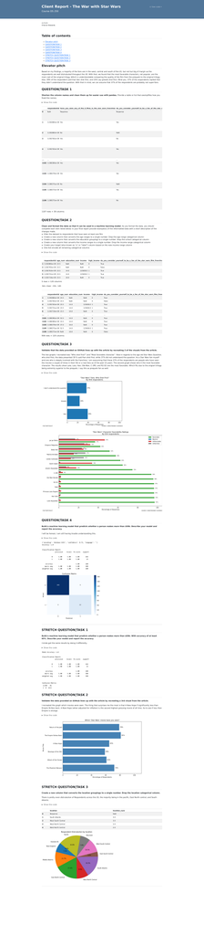

Table of contents

Elevator pitch

QUESTION|TASK 1

QUESTION|TASK 2

QUESTION|TASK 3

QUESTION|TASK 4

STRETCH QUESTION|TASK 1

STRETCH QUESTION|TASK 2

STRETCH QUESTION|TASK 3

Elevator pitch

Based on my ﬁndings, a majority of the fans are in the west, central and south of the US. but not but big of margin as the

respondents are well distrubuted througout the US. With that, we found that the most favorable characters, not popular, are the

main cast of the original trilogy. Which is understandable comparing the quality of the ﬁlm from the prequels to the original trilogy.

Also, 39% of the respondent said that Han shot ﬁrst, and 24% say greedo shot ﬁrst. Mind you, 37% of the respondents replied that

they didn’t understand the question. With that in mind, we can assume that 37% of the respondents are probably not super-fans.

QUESTION|TASK 1

Shorten the column names and clean them up for easier use with pandas. Provide a table or list that exempliﬁes how you

ﬁxed the names.

Show the code

respondentid have_you_seen_any_of_the_6_ﬁlms_in_the_star_wars_franchise do_you_consider_yourself_to_be_a_fan_of_the_star_w

0 NaN Response Response

1 3.292880e+09 Yes Yes

2 3.292880e+09 No NaN

3 3.292765e+09 Yes No

4 3.292763e+09 Yes Yes

... ... ... ...

1182 3.288389e+09 Yes Yes

1183 3.288379e+09 Yes Yes

1184 3.288375e+09 No NaN

1185 3.288373e+09 Yes Yes

1186 3.288373e+09 Yes No

1187 rows × 38 columns

QUESTION|TASK 2

Clean and format the data so that it can be used in a machine learning model. As you format the data, you should

complete each item listed below. In your ﬁnal report provide example(s) of the reformatted data with a short description of the

changes made.

a. Filter the dataset to respondents that have seen at least one ﬁlm

a. Create a new column that converts the age ranges to a single number. Drop the age range categorical column

a. Create a new column that converts the education groupings to a single number. Drop the school categorical column

a. Create a new column that converts the income ranges to a single number. Drop the income range categorical column

a. Create your target (also known as “y” or “label”) column based on the new income range column

a. One-hot encode all remaining categorical columns

Show the code

respondentid age_num education_num income high_income do_you_consider_yourself_to_be_a_fan_of_the_star_wars_ﬁlm_franchise

1 3.292880e+09 23.5 NaN NaN 0 True

3 3.292765e+09 23.5 NaN NaN 0 False

4 3.292763e+09 23.5 14.0 125000.0 1 True

5 3.292731e+09 23.5 14.0 125000.0 1 True

6 3.292719e+09 23.5 16.0 NaN 0 True

5 rows × 120 columns

Data shape: (936, 120)

respondentid age_num education_num income high_income do_you_consider_yourself_to_be_a_fan_of_the_star_wars_ﬁlm_franc

1 3.292880e+09 23.5 NaN NaN 0 True

3 3.292765e+09 23.5 NaN NaN 0 False

4 3.292763e+09 23.5 14.0 125000.0 1 True

5 3.292731e+09 23.5 14.0 125000.0 1 True

6 3.292719e+09 23.5 16.0 NaN 0 True

... ... ... ... ... ... ...

1181 3.288390e+09 52.5 14.0 NaN 0 True

1182 3.288389e+09 23.5 14.0 NaN 0 True

1183 3.288379e+09 37.0 16.0 NaN 0 True

1185 3.288373e+09 52.5 14.0 125000.0 1 True

1186 3.288373e+09 NaN 18.0 NaN 0 False

936 rows × 120 columns

QUESTION|TASK 3

Validate that the data provided on GitHub lines up with the article by recreating 2 of the visuals from the article.

The two graphs I recreated was “Who shot ﬁrst?” and “Most favorable character”. Now in regards to the age old Star Wars Question,

who shot ﬁrst, the data presented 39 % said Han shot ﬁrst, while 37% did not understand the question. As a Star Wars fan myself

and one who is deeply involved with the franchise, I am assouming that those 37% of the respondents are people who have seen

the movies a couple of times in their life or a new fans as of the past 10 years. The second graph shows who it the most favorable

character. The results show Luke, Leia, Han, Obi-Wan, C-3P0, and R2-D2 are the most favorable. Which ﬁts due to the origianl trilogy

being extremly superior to the prequels. I say this as prequels fan as well.

Show the code

QUESTION|TASK 4

Build a machine learning model that predicts whether a person makes more than $50k. Describe your model and

report the accuracy.

I will be honest, I am still having trouble understanding this.

Show the code

{'encoding': 'Windows-1252', 'confidence': 0.73, 'language': ''}

Accuracy: 1.0

Classification Report:

precision recall f1-score support

0 1.00 1.00 1.00 166

1 1.00 1.00 1.00 22

accuracy 1.00 188

macro avg 1.00 1.00 1.00 188

weighted avg 1.00 1.00 1.00 188

STRETCH QUESTION|TASK 1

Build a machine learning model that predicts whether a person makes more than $50k. With accuracy of at least

65%. Describe your model and report the accuracy.

I kinda got the same results by doing it diﬀerently.

Show the code

Model Accuracy: 1.0

Classification Report:

precision recall f1-score support

0 1.00 1.00 1.00 166

1 1.00 1.00 1.00 22

accuracy 1.00 188

macro avg 1.00 1.00 1.00 188

weighted avg 1.00 1.00 1.00 188

Confusion Matrix:

[[166 0]

[ 0 22]]

STRETCH QUESTION|TASK 2

Validate the data provided on GitHub lines up with the article by recreating a 3rd visual from the article.

I recreated the graph which movies were seen. The thing that surprises me the most is that A New Hope if signiﬁcantly less than

Empire Strikes back. A New Hope (when adjusted for inﬂation) is the second highest grossing movie of all time. So to see if less than

Empire is strange.

Show the code

STRETCH QUESTION|TASK 3

Create a new column that converts the location groupings to a single number. Drop the location categorical column.

There is pretty even distrubution of Respondents across the US, the mojority being in the paciﬁc, East North central, and South

Atlantic.

Show the code

location location_num

0 Response NaN

1 South Atlantic 3.0

2 West South Central 3.0

3 West North Central 2.0

4 West North Central 2.0

Client Report - The War with Star Wars

See code

Course DS 250

Chance Edwards

AUTHOR